# SML_Work1_411278018

## 第一次作品：群組資料的主成分分析實驗

| **學號** | 411278018 |
| --- | --- |
| **姓名** | 蕭本豫 |

**作品目標**：

本作品以兩組多變量分群資料為例，運用主成分分析進行降維，同時維持良好的群組判別能力。分析內容涵蓋資料特徵的解讀、各式統計圖形的輔助呈現、主成分的選取依據，以及主成分負荷量所反映的變數結構等面向，逐步展開探討。透過這一系列分析，可更清楚理解主成分分析在機器學習中作為特徵擷取方法的角色，不僅能降低資料維度以提升運算效率，也可能增進分群表現。

**目錄**

1. **Quality of Life Index by City 2026（城市生活品質）**
   - 資料讀取與群組標籤設定
   - 標準化與主成分分析（PCA）
   - 主成分負荷量（Loadings）
   - PC1、PC2 平面上的群組分析
2. **乳癌患者腫瘤的影像量測資料（Breast Cancer）**
   - 資料匯入及探索
   - 標準化與主成分分析（PCA）
   - 主成分負荷量（Loadings）
   - PC1、PC2 平面上的群組分析
3. **總結論**

**預先載入套件與函數：**

```python
import numpy as np
import pandas as pd
import scipy.stats as stats
import matplotlib.pyplot as plt
```

**1：Quality of Life Index by City 2026**

- 內容：2026 年世界城市生活品質指標
- 來源：NUMBEO https://www.numbeo.com/quality-of-life/rankings.jsp?title=2026
- 數量：304 個城市的指標數字
- 特徵：8 個與城市相關的面向指標
- 群組標籤：無。但可依生活品質總分（Quality of Life Index）分為若干個群組，譬如依總分大小分為 3 或 4 群（按實際分布），並給予群組標籤。假設分 3 個群組，則給予 H, M, L 分別代表高品質、中品質與低品質城市。

**資料讀取與群組標籤設定**：

首先讀入 NUMBEO 的城市生活品質資料，取出其八個指標作為特徵，並依照生活品質總分（Quality of Life Index）將城市分為高（H）、中（M）、低（L）三群。

```python
df = pd.read_excel("2026_city_quality.xlsx")

score = df['Quality of Life Index']  # 以生活品質總分劃分為高中低三群

q1, q2 = score.quantile([1/3, 2/3])  #  依[1/3, 2/3]分位數劃分
def label_group(s):
    if s >= q2:
        return 'H'
    elif s >= q1:
        return 'M'
    else:
        return 'L'

df['Group'] = score.apply(label_group)

features = ['Purchasing Power Index',
            'Safety Index',
            'Health Care Index',
            'Cost of Living Index',
            'Property Price to Income Ratio',
            'Traffic Commute Time Index',
            'Pollution Index',
            'Climate Index']

X = df[features].values
groups = df['Group'].values
```

**標準化與主成分分析（PCA）**：

先對八個特徵做標準化處理，使其均值為 0、變異數為 1，以避免尺度影響 PCA。再進行主成分分析（PCA），觀察各個主成分的解釋變異比例與累積解釋變異，作為選取主成分個數的依據。

```
各主成分解釋變異比例: [0.41749647 0.16449145 0.12783124 0.10320303 0.06984314 0.05862988
 0.0380803  0.0204245 ]
累積解釋變異比例: [0.41749647 0.58198791 0.70981915 0.81302218 0.88286532 0.9414952
 0.9795755  1.        ]
```

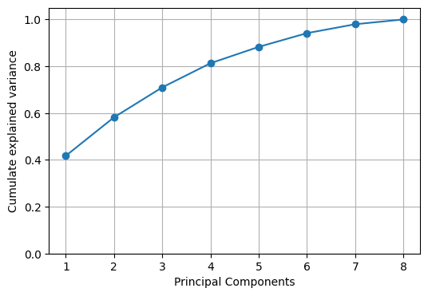

```python
from sklearn.preprocessing import StandardScaler
from sklearn.decomposition import PCA

# Standardize
scaler = StandardScaler()
X_std = scaler.fit_transform(X)

pca_full = PCA()
X_pca_full = pca_full.fit_transform(X_std)

explained_var = pca_full.explained_variance_ratio_
cum_explained_var = np.cumsum(explained_var)

print("各主成分解釋變異比例:", explained_var)
print("累積解釋變異比例:", cum_explained_var)
plt.figure(figsize=(6,4))
plt.plot(range(1, len(explained_var)+1), cum_explained_var, marker='o')
plt.xlabel('Principal Components')
plt.ylabel('Cumulate explained variance')
plt.ylim(0, 1.05)
plt.grid(True)
plt.show()
```

從數據可知，各主成分的解釋變異比例如下：

- **PC1**：解釋約 **41.7%** 的總變異
- **PC2**：解釋約 **16.4%** 的總變異
- **PC3**：解釋約 **12.7%** 的總變異
- **PC4**：解釋約 **10.3%** 的總變異

前四主成分累積解釋約 **81.3%** 的總變異，若以資訊保留為考量，可視為主要的解釋空間。然而，為方便二維視覺化與解釋，後續圖形分析仍以 PC1 與 PC2 為主。

**主成分負荷量（Loadings）：**

檢視各個主成分的負荷量，了解這八個原始變數在主成分上的權重大小及正負，以詮釋主成分代表之含義。

```python
loadings = pd.DataFrame(pca_full.components_.T, columns=[f'PC{i+1}' for i in range(len(features))], index=features)
loadings[['PC1', 'PC2']]
```

|  | PC1 | PC2 |
| --- | --- | --- |
| Purchasing Power Index | -0.460889 | -0.185924 |
| Safety Index | -0.179975 | 0.694186 |
| Health Care Index | -0.353497 | 0.132321 |
| Cost of Living Index | -0.435775 | -0.238973 |
| Property Price to Income Ratio | 0.330978 | 0.275787 |
| Traffic Commute Time Index | 0.330917 | -0.315053 |
| Pollution Index | 0.470401 | -0.010394 |
| Climate Index | 0.000521 | -0.483214 |

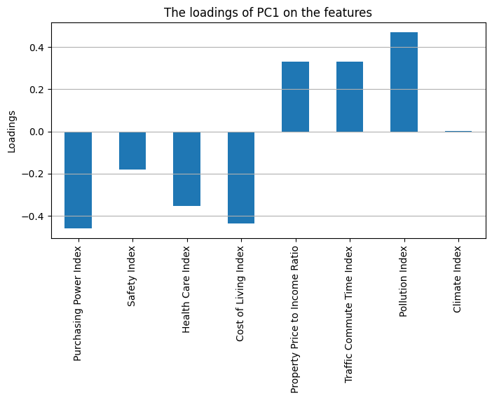

```python
# Or, draw a barplot
plt.figure(figsize=(8,4))
loadings['PC1'].plot(kind='bar')
plt.ylabel('Loadings')
plt.title('The loadings of PC1 on the features')
plt.grid(axis='y')
plt.show()
```

由圖可以清楚地看見，在 PC1 中各變數負荷量的特徵如下：

- **Pollution Index**（+0.47）：負荷量為正且最大，表示 PC1 高的城市污染較嚴重
- **Traffic Commute Time Index**、**Property Price to Income Ratio**（約 +0.33）：負荷量為正，代表通勤時間較長、房價所得比較高
- **Purchasing Power Index**（−0.46）、**Cost of Living Index**（−0.44）：負荷量為負，表示 PC1 高的城市購買力較低

因此，**PC1 數值愈高**代表城市整體生活條件愈差（高污染、低購買力）；**PC1 數值愈低**則代表城市生活品質愈佳，可詮釋為**反向的生活品質綜合指標**。

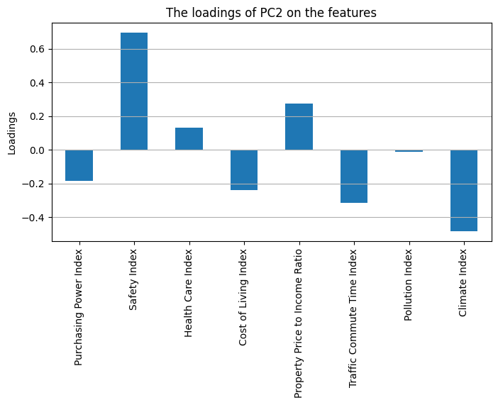

```python
# Or, draw a barplot
plt.figure(figsize=(8,4))
loadings['PC2'].plot(kind='bar')
plt.ylabel('Loadings')
plt.title('The loadings of PC2 on the features')
plt.grid(axis='y')
plt.show()
```

**Safety Index** 在 PC2 上負荷量最大（約 +0.69），而 **Climate Index** 負荷量為負（約 −0.48）。因此 **PC2** 可詮釋為安全感與氣候舒適度之間的對比指標：PC2 愈高代表城市安全感較強，但氣候評分相對較低。

**PC1、PC2 平面上的群組分析：**

利用前兩個主成分構成的平面，以散布圖呈現各城市位置，並以顏色標示 H、M、L 三群，檢視 PCA 降維後是否仍具有良好的群組判別能力。

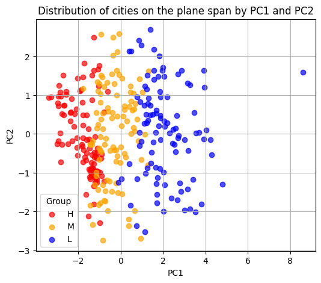

```python
pca_2 = PCA(n_components=2)
X_pca_2 = pca_2.fit_transform(X_std)

pc1 = X_pca_2[:, 0]
pc2 = X_pca_2[:, 1]

group_colors = {'H': 'red', 'M': 'orange', 'L': 'blue'}

plt.figure(figsize=(6,5))
for g in ['H', 'M', 'L']:
    idx = (groups == g)
    plt.scatter(pc1[idx], pc2[idx],
                c=group_colors[g], label=g, alpha=0.7)
plt.xlabel('PC1')
plt.ylabel('PC2')
plt.legend(title='Group')
plt.title('Distribution of cities on the plane span by PC1 and PC2')
plt.grid(True)
plt.show()
```

在 PC1–PC2 平面上的散布圖中，可觀察到三群城市的分布具有明顯的排序關係：

- **H 群**（紅色）：多集中在 PC1 **較低**的區域（低污染、高購買力）
- **M 群**（橘色）：大致分布在中間位置
- **L 群**（藍色）：主要出現在 PC1 **較高**的一側（高污染、低購買力）

結合前述主成分負荷量，PC1 數值愈高代表城市生活條件愈差，因此三個群組在 PC1 上形成 **H → M → L** 的有序分離（由左至右品質遞減）。此結果顯示，在僅保留前兩個主成分（累積解釋約 **58.1%** 變異）的情況下，PCA 仍能相當良好地保留原本依生活品質總分劃分之群組結構與判別能力。

**2：乳癌患者腫瘤的影像量測資料**

- 內容：乳癌患者腫瘤的影像量測資料
- 來源：UCI Machine Learning Repository 的 Breast Cancer Wisconsin (Diagnostic) Dataset。實際資料可從 sklearn 下載。
- 數量：569 位患者
- 特徵：30 個量測變數（由乳房腫瘤細針抽吸，以 FNA 影像計算出的細胞核特徵）
- 標籤：Malignant（惡性腫瘤）與 Benign（良性腫瘤）

**資料匯入及探索：**

首先從 sklearn 載入乳癌資料集，共包含 569 位患者的 30 個細胞核量測特徵，並確認惡性（Malignant，0）與良性（Benign，1）兩群的樣本數量分布。

```python
from sklearn.datasets import load_breast_cancer
data = load_breast_cancer()
X = data.data
y = data.target # 0: malignant, 1: benign

# 確認資料為度以及兩群數量分布。
df = pd.DataFrame(X, columns=data.feature_names)
df['Group'] = y
print(df.shape)
print(df['Group'].value_counts())
df.head()
```

```
(569, 31)
Group
1    357
0    212
Name: count, dtype: int64
```

|  | mean radius | mean texture | mean perimeter | mean area | mean smoothness | mean compactness | mean concavity | mean concave points | mean symmetry | mean fractal dimension | ... | worst texture | worst perimeter | worst area | worst smoothness | worst compactness | worst concavity | worst concave points | worst symmetry | worst fractal dimension | Group |
| --- | --- | --- | --- | --- | --- | --- | --- | --- | --- | --- | --- | --- | --- | --- | --- | --- | --- | --- | --- | --- | --- |
| 0 | 17.99 | 10.38 | 122.80 | 1001.0 | 0.11840 | 0.27760 | 0.3001 | 0.14710 | 0.2419 | 0.07871 | ... | 17.33 | 184.60 | 2019.0 | 0.1622 | 0.6656 | 0.7119 | 0.2654 | 0.4601 | 0.11890 | 0 |
| 1 | 20.57 | 17.77 | 132.90 | 1326.0 | 0.08474 | 0.07864 | 0.0869 | 0.07017 | 0.1812 | 0.05667 | ... | 23.41 | 158.80 | 1956.0 | 0.1238 | 0.1866 | 0.2416 | 0.1860 | 0.2750 | 0.08902 | 0 |
| 2 | 19.69 | 21.25 | 130.00 | 1203.0 | 0.10960 | 0.15990 | 0.1974 | 0.12790 | 0.2069 | 0.05999 | ... | 25.53 | 152.50 | 1709.0 | 0.1444 | 0.4245 | 0.4504 | 0.2430 | 0.3613 | 0.08758 | 0 |
| 3 | 11.42 | 20.38 | 77.58 | 386.1 | 0.14250 | 0.28390 | 0.2414 | 0.10520 | 0.2597 | 0.09744 | ... | 26.50 | 98.87 | 567.7 | 0.2098 | 0.8663 | 0.6869 | 0.2575 | 0.6638 | 0.17300 | 0 |
| 4 | 20.29 | 14.34 | 135.10 | 1297.0 | 0.10030 | 0.13280 | 0.1980 | 0.10430 | 0.1809 | 0.05883 | ... | 16.67 | 152.20 | 1575.0 | 0.1374 | 0.2050 | 0.4000 | 0.1625 | 0.2364 | 0.07678 | 0 |

5 rows × 31 columns

資料集共有 **569** 筆、**30** 個特徵，兩群分布如下：

- **Benign（良性，1）**：357 筆（約 62.7%）
- **Malignant（惡性，0）**：212 筆（約 37.3%）

樣本存在一定程度的類別不平衡，良性樣本約為惡性樣本的 1.7 倍。後續將以此標籤作為 PCA 降維後的群組判別依據。

**標準化與主成分分析（PCA）：**

對 30 個特徵進行標準化處理，使各特徵的均值為 0、變異數為 1，以避免量綱差異影響 PCA 結果。接著進行完整 PCA，觀察各主成分的解釋變異比例與累積解釋變異，作為選取主成分個數的依據。

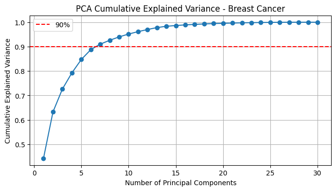

```python
from sklearn.preprocessing import StandardScaler
from sklearn.decomposition import PCA
import matplotlib.pyplot as plt
import numpy as np

scaler = StandardScaler()
X_std = scaler.fit_transform(X)

pca_full = PCA()
pca_full.fit(X_std)

explained_var = pca_full.explained_variance_ratio_
cum_var = np.cumsum(explained_var)

plt.figure(figsize=(8, 4))
plt.plot(range(1, len(explained_var)+1), cum_var, marker='o')
plt.axhline(y=0.9, color='r', linestyle='--', label='90%')
plt.xlabel('Number of Principal Components')
plt.ylabel('Cumulative Explained Variance')
plt.title('PCA Cumulative Explained Variance - Breast Cancer')
plt.legend()
plt.grid(True)
plt.show()
```

從累積解釋變異圖可知，30 個特徵之間存在高度的線性相關結構：

- **PC1**：解釋約 **44.3%** 的總變異
- **PC2**：解釋約 **18.9%** 的總變異
- 前兩個主成分累積解釋約 **63.2%**，約 **7 個**主成分即可達 90%

相較於第一題（8 個特徵），第二題的 30 個特徵維度雖然高得多，但前幾個主成分仍能捕捉大部分的資訊結構，顯示這批細胞核量測指標之間具有強烈的共變異性，適合以 PCA 降維。後續群組分析仍以 **PC1 與 PC2** 為主要觀察平面。

**主成分負荷量（Loadings）：**

檢視各主成分的負荷量，了解 30 個原始量測變數在主成分上的權重大小及正負，以詮釋各主成分所代表的生物意義。

```
                              PC1       PC2
mean concave points      0.260854 -0.034768
mean concavity           0.258400  0.060165
worst concave points     0.250886 -0.008257
mean compactness         0.239285  0.151892
worst perimeter          0.236640 -0.199878
worst concavity          0.228768  0.097964
worst radius             0.227997 -0.219866
mean perimeter           0.227537 -0.215181
worst area               0.224871 -0.219352
mean area                0.220995 -0.231077
mean radius              0.218902 -0.233857
perimeter error          0.211326 -0.089457
worst compactness        0.210096  0.143593
radius error             0.205979 -0.105552
area error               0.202870 -0.152293
concave points error     0.183417  0.130322
compactness error        0.170393  0.232716
concavity error          0.153590  0.197207
mean smoothness          0.142590  0.186113
mean symmetry            0.138167  0.190349
worst fractal dimension  0.131784  0.275339
worst smoothness         0.127953  0.172304
worst symmetry           0.122905  0.141883
worst texture            0.104469 -0.045467
mean texture             0.103725 -0.059706
fractal dimension error  0.102568  0.280092
mean fractal dimension   0.064363  0.366575
symmetry error           0.042498  0.183848
texture error            0.017428  0.089980
smoothness error         0.014531  0.204430
```

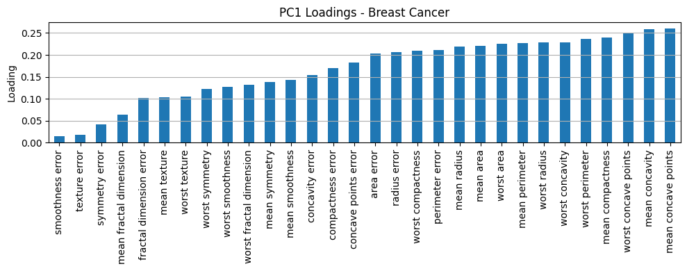

```python
loadings = pd.DataFrame(
    pca_full.components_.T,
    columns=[f'PC{i+1}' for i in range(30)],
    index=data.feature_names
)

# 只看PC1、PC2
print(loadings[['PC1', 'PC2']].sort_values('PC1', ascending=False))

# 視覺化 PC1
plt.figure(figsize=(10, 4))
loadings['PC1'].sort_values().plot(kind='bar')
plt.ylabel('Loading')
plt.title('PC1 Loadings - Breast Cancer')
plt.tight_layout()
plt.grid(axis='y')
plt.show()
```

**PC1、PC2 平面上的群組分析：**

利用前兩個主成分構成的平面，以散布圖呈現各患者的位置，並以顏色標示 Malignant（惡性，紅色）與 Benign（良性，藍色）兩群，檢視 PCA 降維後是否仍具有良好的群組判別能力。

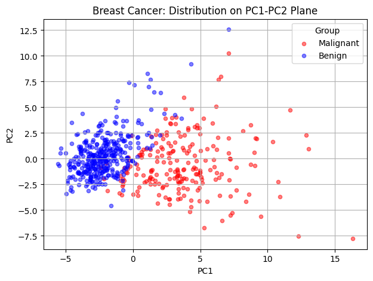

```python
pca_2 = PCA(n_components=2)
X_pca_2 = pca_2.fit_transform(X_std)

group_labels = {0: 'Malignant', 1: 'Benign'}
group_colors = {0: 'red', 1: 'blue'}

plt.figure(figsize=(7, 5))
for g in [0, 1]:
    idx = (y == g)
    plt.scatter(X_pca_2[idx, 0], X_pca_2[idx, 1],
                c=group_colors[g], label=group_labels[g], alpha=0.5, s=20)
plt.xlabel('PC1')
plt.ylabel('PC2')
plt.title('Breast Cancer: Distribution on PC1-PC2 Plane')
plt.legend(title='Group')
plt.grid(True)
plt.show()
```

在 PC1–PC2 平面上的散布圖中，兩群患者的分布具有相當明顯的分離：

- **Malignant（惡性，紅色）**：多集中在 PC1 較高的一側
- **Benign（良性，藍色）**：多集中在 PC1 較低的一側

兩群在 PC1 方向上重疊程度低，顯示 PC1 對惡性程度具有高度的判別力。結合負荷量分析，PC1 主要捕捉腫瘤的尺寸與形狀特徵，而惡性腫瘤通常具有較大的半徑、面積與凹陷點數，因此在 PC1 上呈現顯著偏移。在僅保留前兩個主成分（累積解釋約 **63.2%** 變異）的情況下，群組判別能力仍相當良好。

**總結論：**

本作品以兩組不同性質的資料集，驗證了主成分分析（PCA）在群組資料降維上的有效性：

**第一題（城市生活品質，8 個特徵，3 群）**

- 前兩個主成分累積解釋約 **58.1%** 的總變異，前四個主成分達 **81.3%**
- **PC1** 為反向的生活品質綜合指標（高 PC1 = 高污染、低購買力）；**PC2** 反映安全感與氣候舒適度的對比
- 在 PC1–PC2 平面上，H、M、L 三群城市呈現 **H → M → L** 的有序分離

兩組分析均顯示，PCA 在大幅降低特徵維度的同時，仍能有效保留原始群組的判別結構，驗證其作為機器學習特徵擷取工具的實用性。